# 200628_DCC_paper_analysis_followalong

Evan Witt

6/28/2020

## R Markdown

Welcome to the source code for Witt and Zhao 2019/2020. In order to follow along you will need to obtain the data files from the included box link. This includes the integrated dataset for the two *D. melanogaster* strains, lists of X, Y and testis specific genes, counts from X, Y and autosomes for every gene in every cell, and coordinates for msl chromatin entry sites.

First, let’s set everything up. If you downloaded the data files somewhere else, set your working directory appropriately.

```r
setwd("~/Downloads/WittZhao2020data")
library(Seurat)
library(viridis)
library(MASS)
library(plyr)
library(dplyr)
library(sctransform)
library(hues)
library(ggpubr)
library(ggsignif)
library(tidyverse)
library(rstatix)
library(cowplot)
library(magick)

#This is for times we want to represent p values as asterisks
symnum.args <- list(
  cutpoints = c(0, 0.0001, 0.001, 0.01, 0.05, 1),
  symbols = c("****", "***", "**", "*", "")
)

#read in the tesis RDS, and gene lists- change to wherever you downloaded the data files
testis.integrated<-readRDS("~/Downloads/WittZhao2020data/190730_R517_wild_integrated_SCtransform.RDS")
#testis.integrated<-readRDS("~/Box Sync/Evan/Zhao lab notebook/Misc data/200224_testis_integrated_revision.RDS")
keep= rownames(testis.integrated)[grep("merged",rownames(testis.integrated), invert = T)]

testis.integrated <- subset(x = testis.integrated,features =c(1:(dim(testis.integrated)[1]))[keep])



testis.integrated@active.ident<-factor(testis.integrated@active.ident, levels=c("Hub cells", "Cyst cells", "Epithelial cells", "GSC, Early spermatogonia", "Late spermatogonia", "Early spermatocytes", "Late spermatocytes", "Early spermatids", "Late spermatids"))

testisspecificgenes<-read.csv( "~/Downloads/WittZhao2020data/190516_testisspecificgenes_flyatlas.csv")
names(testisspecificgenes)<-c("row","ID")
genestsv<-read.table("~/Downloads/WittZhao2020data/genes.tsv")
names(genestsv)<-c("ID", "Gene")
X <-(scan("~/Downloads/WittZhao2020data/X.txt", what="", sep="\n"))
X<-X[X %in% rownames(GetAssayData(object = testis.integrated))]

Y <-(scan("~/Downloads/WittZhao2020data/ChrY.txt", what="", sep="\n"))
Y<-Y[Y %in% rownames(GetAssayData(object = testis.integrated))]
autosomal <-rownames(GetAssayData(object = testis.integrated))
autosomal <-autosomal[!autosomal %in% X]
autosomal <-autosomal[!autosomal %in% Y]

testisspecificgenes<-join(testisspecificgenes,genestsv, by="ID", type="inner" )
testisspecificgenes<-droplevels(testisspecificgenes$Gene)
testisspecificgenes<-testisspecificgenes[testisspecificgenes %in% rownames(GetAssayData(object = testis.integrated))]
```

Make a dotplot of all the marker genes in every cell type, then get the barcodes of each cell of every type. Then get the raw counts from every gene, divided by cell type.

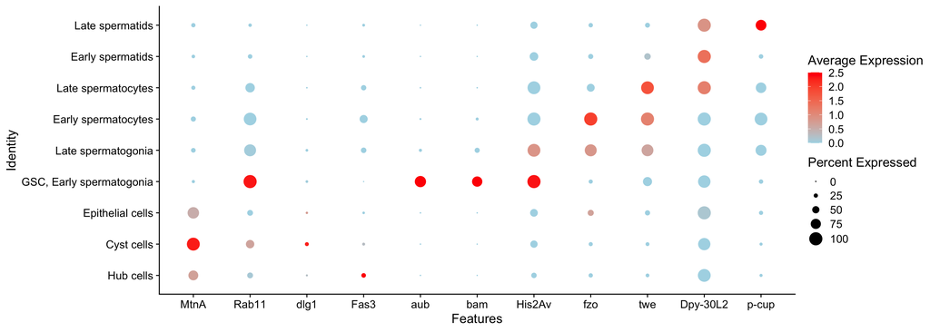

```r
DotPlot(testis.integrated, assay = "RNA", features = rev(c("MtnA","Rab11", "dlg1","Fas3", "aub", "bam", "His2Av", "fzo", "twe", "Dpy-30L2", "p-cup")), cols=c("lightblue", "red"), col.min = 0)
```

```r
#barcodes
Hub <-as.matrix(subset(Idents(testis.integrated), Idents(testis.integrated)=="Hub cells"))
Cyst <-as.matrix(subset(Idents(testis.integrated), Idents(testis.integrated)=="Cyst cells"))
Epi <-as.matrix(subset(Idents(testis.integrated), Idents(testis.integrated)=="Epithelial cells"))
GSC.Early.spermatogonia <-as.matrix(subset(Idents(testis.integrated), Idents(testis.integrated)=="GSC, Early spermatogonia"))
Late.spermatogonia <-as.matrix(subset(Idents(testis.integrated), Idents(testis.integrated)=="Late spermatogonia"))
Early.spermatocytes <-as.matrix(subset(Idents(testis.integrated), Idents(testis.integrated)=="Early spermatocytes"))
Late.spermatocytes <-as.matrix(subset(Idents(testis.integrated), Idents(testis.integrated)=="Late spermatocytes"))
Early.spermatids <-as.matrix(subset(Idents(testis.integrated), Idents(testis.integrated)=="Early spermatids"))
Late.spermatids <-as.matrix(subset(Idents(testis.integrated), Idents(testis.integrated)=="Late spermatids"))

#raw counts
Hub.raw<-as.matrix(testis.integrated@assays$RNA@counts[,rownames(Hub)])
Cyst.raw<-as.matrix(testis.integrated@assays$RNA@counts[,rownames(Cyst)])
Epithelial.raw<-as.matrix(testis.integrated@assays$RNA@counts[,rownames(Epi)])
GSC.Early.spermatogonia.raw<-as.matrix(GetAssayData(object=testis.integrated, slot="counts")[,rownames(GSC.Early.spermatogonia)])
Late.spermatogonia.raw<-as.matrix(GetAssayData(object=testis.integrated, slot="counts")[,rownames(Late.spermatogonia )])
Early.spermatocytes.raw<-as.matrix(GetAssayData(object=testis.integrated, slot="counts")[,rownames(Early.spermatocytes)])
Late.spermatocytes.raw<-as.matrix(GetAssayData(object=testis.integrated, slot="counts")[,rownames(Late.spermatocytes)])
Early.spermatids.raw<-as.matrix(GetAssayData(object=testis.integrated, slot="counts")[,rownames(Early.spermatids)])
Late.spermatids.raw<-as.matrix(GetAssayData(object=testis.integrated, slot="counts")[,rownames(Late.spermatids)])
```

Ok let’s make figure 1.

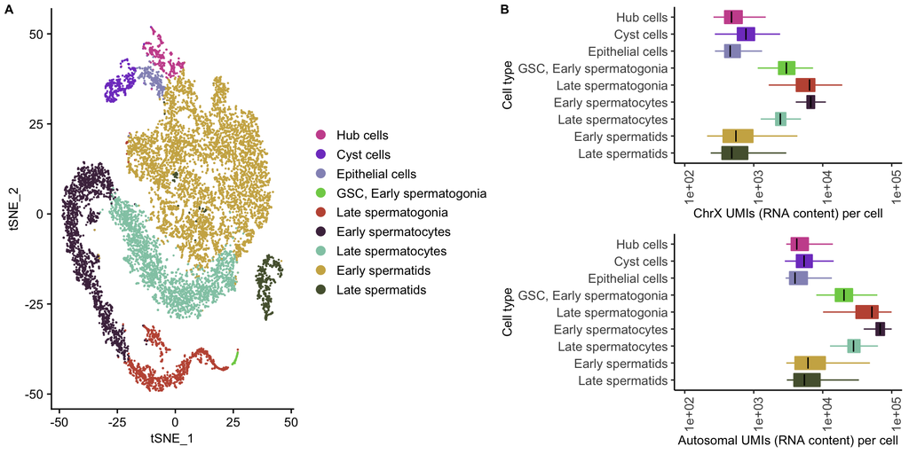

```r
#make a color palette for our 9 cell types
pal<-as.vector(iwanthue(n = 9))


#make boxplots  plot of RNA for X, autosomes
Xcounts<-colSums(as.matrix(testis.integrated@assays$RNA@counts)[X,])
Autocounts<-colSums(as.matrix(testis.integrated@assays$RNA@counts)[autosomal,])
testis.integrated<-AddMetaData(testis.integrated,metadata = Xcounts, col.name = "Xcounts")
testis.integrated<-AddMetaData(testis.integrated,metadata = Autocounts, col.name = "Autocounts")

data1<-data.frame(Xcounts=testis.integrated@meta.data$Xcounts, Autocounts=testis.integrated@meta.data$Autocounts, Celltype=testis.integrated@active.ident )

data1$Celltype<-factor(data1$Celltype, levels=rev(c("Hub cells", "Cyst cells", "Epithelial cells", "GSC, Early spermatogonia", "Late spermatogonia", "Early spermatocytes", "Late spermatocytes", "Early spermatids", "Late spermatids")))

#get median RNA counts for every cell type, X and autosome
celltypecounts<-data.frame()
for (i in unique(data1$Celltype)){
  tmp<-data.frame(Celltype=i, Xcounts=median(subset(data1, Celltype==i)$Xcounts), Autocounts=median(subset(data1, Celltype==i)$Autocounts))
  celltypecounts<-rbind(tmp, celltypecounts)
}


#Figure 1B
p1<-ggplot(data1, aes(x=data1$Celltype, y=Xcounts))+geom_boxplot(outlier.shape = NA, aes(x = Celltype, group=Celltype, fill=Celltype, color=Celltype))+theme_classic()+theme(legend.position="none")+scale_color_manual(aesthetics = c("color","fill"),values = rev(pal))+
stat_summary(geom = "crossbar", width=0.6, position= position_dodge(width = 0.75), fatten=0, color="black", fun.data = function(x){ return(c(y=median(x), ymin=median(x), ymax=median(x))) })+ scale_y_log10(limits=c(100, 100000))+xlab("Cell type")+ ylab("ChrX UMIs (RNA content) per cell")+coord_flip()+
  theme(axis.text.x=element_text(angle=90, size=10), axis.title=element_text(size=10) ,axis.text.y=element_text(size=10))

p2<-ggplot(data1, aes(x=data1$Celltype, y=Autocounts))+geom_boxplot(outlier.shape = NA, aes(x = Celltype, group=Celltype, fill=Celltype, color=Celltype))+theme_classic()+theme(legend.position="none")+scale_color_manual(aesthetics = c("color","fill"),values = rev(pal))+
stat_summary(geom = "crossbar", width=0.6, position= position_dodge(width = 0.75), fatten=0, color="black", fun.data = function(x){ return(c(y=median(x), ymin=median(x), ymax=median(x))) })+  scale_y_log10(limits=c(100, 100000))+xlab("Cell type")+ ylab("Autosomal UMIs (RNA content) per cell")+coord_flip()+
  theme(axis.text.x=element_text(angle=90, size=10), axis.title=element_text(size=10) ,axis.text.y=element_text(size=10))

p1<-plot_grid(p1, p2, ncol=1, rel_widths=c(1,1))
#Figure 1A- make t-sNE showing dimensional reduction of cell types
p2 <- DimPlot(testis.integrated, reduction = "tsne", label = FALSE , cols = pal)
p2<-p2+theme(text=element_text(size=10), axis.text=element_text(size=10), axis.title=element_text(size=10), legend.text=element_text(size=10))
p1<-p1+theme(text=element_text(size=10), axis.text=element_text(size=10), axis.title=element_text(size=10), legend.text=element_text(size=10))

p1 <-plot_grid(p2, p1, rel_widths = c(1.2,1) ,labels = c("A", "B"), label_size = 10)


#plot_grid(p1, p2, ncol=1, labels = c("A", "C"), label_size = 10, rel_heights = c(0.8,1.5))
p1
```

```r
ggsave( "~/Box Sync/Evan/Zhao lab notebook/Writing/DC paper revisions/200325_figure1.pdf", width=12, height=5)
```

Time for figure 2:

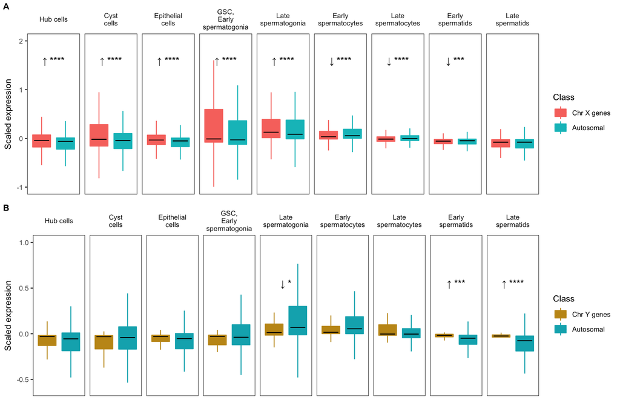

```r
#Get expression of every gene in every cell
testis.scaled<-as.matrix(GetAssayData(testis.integrated, assay  = "RNA"))
#scale every gene so that 0 is its median expression across all cells
testis.scaled<-t(scale(t(testis.scaled)))
testis.scaled[is.nan(testis.scaled)]<-0

#get scaled expression of cells in each celltype
Hub.scale<-as.matrix(testis.scaled[,rownames(Hub)])
Epi.scale<-as.matrix(testis.scaled[,rownames(Epi)])
Cyst.scale<-as.matrix(testis.scaled[,rownames(Cyst)])
GSC.Early.spermatogonia.scale<-as.matrix(testis.scaled[,rownames(GSC.Early.spermatogonia)])
Late.spermatogonia.scale<-as.matrix(testis.scaled[,rownames(Late.spermatogonia )])
Early.spermatocytes.scale<-as.matrix(testis.scaled[,rownames(Early.spermatocytes)])
Late.spermatocytes.scale<-as.matrix(testis.scaled[,rownames(Late.spermatocytes)])
Early.spermatids.scale<-as.matrix(testis.scaled[,rownames(Early.spermatids)])
Late.spermatids.scale<-as.matrix(testis.scaled[,rownames(Late.spermatids)])

#get mean expression of every gene across every celltype
#Somatic.bias <-data.frame(Celltype="Somatic cells", Exp=rowMeans(Somatic.scale), Gene=rownames(Somatic.scale), row.names = NULL)
Hub.bias <-data.frame(Celltype="Hub cells", Exp=rowMeans(Hub.scale), Gene=rownames(Hub.scale), row.names = NULL)
Cyst.bias <-data.frame(Celltype="Cyst cells", Exp=rowMeans(Cyst.scale), Gene=rownames(Cyst.scale), row.names = NULL)
Epi.bias <-data.frame(Celltype="Epithelial cells", Exp=rowMeans(Epi.scale), Gene=rownames(Epi.scale), row.names = NULL)
GSC.Early.spermatogonia.bias <-data.frame(Celltype="GSC, Early spermatogonia", Exp=rowMeans(GSC.Early.spermatogonia.scale), Gene=rownames(GSC.Early.spermatogonia.scale), row.names = NULL)
Late.spermatogonia.bias <-data.frame(Celltype="Late spermatogonia", Exp=rowMeans(Late.spermatogonia.scale), Gene=rownames(Late.spermatogonia.scale), row.names = NULL)
Early.spermatocytes.bias <-data.frame(Celltype="Early spermatocytes", Exp=rowMeans(Early.spermatocytes.scale), Gene=rownames(Early.spermatocytes.scale), row.names = NULL)
Late.spermatocytes.bias <-data.frame(Celltype="Late spermatocytes", Exp=rowMeans(Late.spermatocytes.scale), Gene=rownames(Late.spermatocytes.scale), row.names = NULL)
Early.spermatids.bias <-data.frame(Celltype="Early spermatids", Exp=rowMeans(Early.spermatids.scale), Gene=rownames(Early.spermatids.scale), row.names = NULL)
Late.spermatids.bias <-data.frame(Celltype="Late spermatids", Exp=rowMeans(Late.spermatids.scale), Gene=rownames(Late.spermatids.scale), row.names = NULL)

#makae data frame with scaled epxression of every gene in every cell type
plot.data<-rbind(Hub.bias,Cyst.bias,Epi.bias,GSC.Early.spermatogonia.bias,Late.spermatogonia.bias,Early.spermatocytes.bias,Late.spermatocytes.bias,Early.spermatids.bias,Late.spermatids.bias )
data1 <-data.frame(subset(plot.data, Gene %in% X), "Chr X genes")
data3<-data.frame(subset(plot.data, Gene %in% Y), "Chr Y genes")
data2<-data.frame(subset(plot.data, Gene %in% autosomal), "Autosomal")

library(ggpubr)
names(data1)<-c ("Celltype","Exp", "Gene", "Class" )
names(data2)<-c ("Celltype","Exp", "Gene", "Class" )
names(data3)<-c ("Celltype","Exp", "Gene", "Class" )
#data4 has, for every gene, its mean scaled expression across every cell type
data4 <-rbind(data1, data2, data3)
data4$Class<-factor(data4$Class, levels=c("Chr X genes", "Autosomal","Chr Y genes"))


my_comparisons<-list(c("Chr X genes", "Autosomal"), c("Chr Y genes", "Autosomal"))
#test if gene class affects scaled expression in every cell type, adjusts p value with holms correction
stat.test1 <- data4 %>%
  group_by(Celltype) %>%
  wilcox_test(Exp ~ Class, comparisons = my_comparisons, alternative="greater")
stat.test1 <- stat.test1 %>% add_y_position()
stat.test2 <- data4 %>%
  group_by(Celltype) %>%
  wilcox_test(Exp ~ Class, comparisons = my_comparisons, alternative="less")
stat.test2 <- stat.test2 %>% add_y_position()
stat.test1$p.adj<-p.adjust(stat.test1$p)
stat.test2$p.adj<-p.adjust(stat.test2$p)
stat.test1$p.adj.signif<- symnum(stat.test1$p.adj, corr = FALSE,
                                 cutpoints = c(0,.00005,  .0005,.005,.05,  1),
                                 symbols = c("****","***","**","*"," "))
stat.test2$p.adj.signif<- symnum(stat.test2$p.adj, corr = FALSE,
                                 cutpoints = c(0,.00005,  .0005,.005,.05,  1),
                                 symbols = c("****","***","**","*"," "))

stat.test1<-subset(stat.test1, group2 != "Chr Y genes")
stat.test2<-subset(stat.test2, group2 != "Chr Y genes")
stat.test3<-rbind(stat.test1, stat.test2) #this is for supplemental table 2
#This is to put it in the right place when we plot
stat.test1$y.position<-1.5
stat.test2$y.position<-1.5
#put cute little arrows in to show the relationship between sex chromosome and autosome- up or down
stat.test1$p.adj.signif<-gsub(stat.test1$p.adj.signif, pattern = "^\\*", replacement=paste("\U2191", "*"))
stat.test2$p.adj.signif<-gsub(stat.test2$p.adj.signif, pattern = "^\\*", replacement=paste("\U2193", "*"))
#Don't print NS on plot.  We already have asterisks
stat.test1$p.adj.signif<-gsub(stat.test1$p.adj.signif, pattern = "ns", replacement="")
stat.test2$p.adj.signif<-gsub(stat.test2$p.adj.signif, pattern = "ns", replacement="")
#setting bracket size to 0 puts the p.adj asterixes in between each boxplot.  The rest of the stuff makes the boxpplot, makes it pretty, sets the scale
#First, the X.  Notice that we calculated the statistics first before subsetting the data.
data4<-rbind(data1, data2)
p1<-ggplot(data4, aes(x=Class, y=Exp)) +geom_boxplot(outlier.shape=NA, aes_string(y="Exp", colour="Class", fill="Class"))+facet_wrap(~Celltype, nrow=1,labeller = label_wrap_gen(width=10))+theme_bw()+xlab(NULL) +
  ylab('Scaled expression') +
  stat_summary(geom = "crossbar", width=0.6, position= position_dodge(width = 0.75), fatten=0, color="black", fun.data = function(x){ return(c(y=median(x), ymin=median(x), ymax=median(x))) })+
  theme(panel.grid.major = element_blank(),strip.background = element_blank(), panel.grid.minor = element_blank(), axis.text.x=element_blank(), axis.ticks.x=element_blank())+
   stat_pvalue_manual(stat.test1,remove.bracket = FALSE,bracket.size = 0, label = "p.adj.signif", tip.length = 0.01)+theme(text=element_text(size=10))+
  stat_pvalue_manual(stat.test2,remove.bracket = FALSE,bracket.size = 0,label = "p.adj.signif", tip.length = 0.01)+ylim(-1,2)






#ok same thing with the Y chromosome
data4 <-rbind(data3,data1, data2)
data4$Class<-factor(data4$Class, levels=c("Chr Y genes", "Autosomal","Chr X genes"))
my_comparisons<-list(c("Chr Y genes", "Autosomal"), c( "Autosomal", "Chr X genes"))

stat.test1 <- data4 %>%
  group_by(Celltype) %>%
  wilcox_test(Exp ~ Class ,ref.group = "Chr Y genes",comparisons = my_comparisons, alternative="greater")
stat.test1 <- stat.test1 %>% add_y_position()
stat.test1$y.position<-0.5
stat.test2 <- data4 %>%
  group_by(Celltype) %>%
  wilcox_test(Exp ~ Class, ref.group="Chr Y genes",comparisons = my_comparisons, alternative="less")
stat.test2 <- stat.test2 %>% add_y_position()
stat.test2$y.position<-0.5
stat.test1$p.adj<-p.adjust(stat.test1$p)
stat.test2$p.adj<-p.adjust(stat.test2$p)
stat.test1$p.adj.signif<- symnum(stat.test1$p.adj, corr = FALSE,
                                 cutpoints = c(0,.00005,  .0005,.005,.05,  1),
                                 symbols = c("****","***","**","*"," "))
stat.test2$p.adj.signif<- symnum(stat.test2$p.adj, corr = FALSE,
                                 cutpoints = c(0,.00005,  .0005,.005,.05,  1),
                                 symbols = c("****","***","**","*"," "))
stat.test1<-subset(stat.test1, group2 != "Chr X genes")
stat.test2<-subset(stat.test2, group2 != "Chr X genes")


stat.test1$p.adj.signif<-gsub(stat.test1$p.adj.signif, pattern = "^\\*", replacement=paste("\U2191", "*"))
stat.test2$p.adj.signif<-gsub(stat.test2$p.adj.signif, pattern = "^\\*", replacement=paste("\U2193", "*"))
stat.test1$p.adj.signif<-gsub(stat.test1$p.adj.signif, pattern = "ns", replacement="")
stat.test2$p.adj.signif<-gsub(stat.test2$p.adj.signif, pattern = "ns", replacement="")
stat.test4<-rbind(stat.test1, stat.test2) #this is for supplemental table 3
data4<-rbind(data3, data2)
p2<-ggplot(data4, aes(x=Class, y=Exp)) +geom_boxplot(outlier.shape=NA, aes_string(y="Exp", colour="Class", fill="Class"))+facet_wrap(~Celltype, nrow=1,labeller = label_wrap_gen(width=10))+theme_bw()+xlab(NULL) +
  ylab('Scaled expression') +
  stat_summary(geom = "crossbar", width=0.6, position= position_dodge(width = 0.75), fatten=0, color="black", fun.data = function(x){ return(c(y=median(x), ymin=median(x), ymax=median(x))) })+
  theme(panel.grid.major = element_blank(),strip.background = element_blank(), panel.grid.minor = element_blank(), axis.text.x=element_blank(), axis.ticks.x=element_blank())+
  stat_pvalue_manual(stat.test1,remove.bracket = FALSE,bracket.size = 0,label = "p.adj.signif", tip.length = 0.01)+theme(text=element_text(size=10))+
  stat_pvalue_manual(stat.test2, remove.bracket = FALSE, bracket.size=0,label = "p.adj.signif", tip.length = 0.01)+ylim(-0.6,1)+scale_color_manual(aesthetics = c("color", "fill"), values=c("#C4961A","#00AFBB"))

p3<-plot_grid(p1, p2, nrow=2, labels=c("A", "B"),label_size = 10)
p3
```

```r
#encoding problem: arrows look like boxes. If you want to save this one as a pdf, use quartz




#to save this locally, run this:
#quartz(type="pdf",file= "~/Box Sync/Evan/Zhao lab notebook/Writing/DC paper revisions/200225_figure2.pdf", width=10, height=6.5)
#plot_grid(p3, p2, ncol=1, labels=c("A", "C"), label_size = 10, rel_widths=c(2,1))
#dev.off()
```

Oh boy that was fun, let’s do figure 3!

This chunk takes hours. Don’t run this. To save you some time I put the output of this chunk into a files with the counts for every X and autosomal gene in every cell. Skip to the next part!

```r
data1<-data.frame()
for (i in list( "Hub.raw", "Cyst.raw", "Epithelial.raw", "GSC.Early.spermatogonia.raw", "Late.spermatogonia.raw", "Early.spermatocytes.raw", "Late.spermatocytes.raw", "Early.spermatids.raw", "Late.spermatids.raw")){
  tmp1<-data.frame(get(i))

  for (j in X){
    tmp2<-data.frame(sum(t(tmp1[j,])), j,i, "X")
    names(tmp2)<-c ("Counts", "Genename", "Celltype", "Chr" )
    data1<-rbind(data1, tmp2)

  }
  for (j in autosomal){
    tmp2<-data.frame(sum(t(tmp1[j,])), j,i, "Autosomal")
    names(tmp2)<-c ("Counts", "Genename", "Celltype", "Chr" )
    data1<-rbind(data1, tmp2)

  }
}

data1$Celltype<-gsub(x=data1$Celltype, pattern="Hub.raw", replacement="Hub cells")
data1$Celltype<-gsub(x=data1$Celltype, pattern="Cyst.raw", replacement="Cyst cells")
data1$Celltype<-gsub(x=data1$Celltype, pattern="Epithelial.raw", replacement="Epithelial cells")
data1$Celltype<-gsub(x=data1$Celltype, pattern="GSC.Early.spermatogonia.raw", replacement="GSC, Early spermatogonia")
data1$Celltype<-gsub(x=data1$Celltype, pattern="Late.spermatogonia.raw", replacement="Late spermatogonia")
data1$Celltype<-gsub(x=data1$Celltype, pattern="Early.spermatocytes.raw", replacement="Early spermatocytes")
data1$Celltype<-gsub(x=data1$Celltype, pattern="Late.spermatocytes.raw", replacement="Late spermatocytes")
data1$Celltype<-gsub(x=data1$Celltype, pattern="Early.spermatids.raw", replacement="Early spermatids")
data1$Celltype<-gsub(x=data1$Celltype, pattern="Late.spermatids.raw", replacement="Late spermatids")
data1$Celltype<-factor(data1$Celltype, levels=rev(c("Hub cells", "Cyst cells", "Epithelial cells", "GSC, Early spermatogonia", "Late spermatogonia", "Early spermatocytes", "Late spermatocytes", "Early spermatids", "Late spermatids")))
#write.table(data1, "~/Downloads/WittZhao2020data/190924_X_autosome_counts.txt")
write.table(data1, "~/Box Sync/Evan/Zhao lab notebook/Misc data/200224_X_autosome_counts.txt")
```

You skipped to this part right? Good. Run this chunk, which makes figure 3.

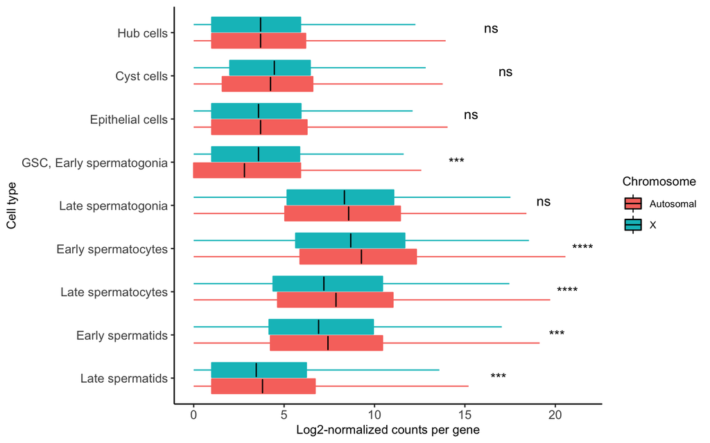

```r
#data1<-read.table("~/Downloads/WittZhao2020data/190924_X_autosome_counts.txt")
data1<-read.table("~/Box Sync/Evan/Zhao lab notebook/Misc data/200224_X_autosome_counts.txt")

data1$Celltype<-factor(data1$Celltype, levels=rev(c("Hub cells", "Cyst cells", "Epithelial cells", "GSC, Early spermatogonia", "Late spermatogonia", "Early spermatocytes", "Late spermatocytes", "Early spermatids", "Late spermatids")))

#get raw and adjusted p values
data2<-data1
data2$Counts<-log2(data2$Counts+1)
stat.test1 <- data2 %>%
  group_by(Celltype) %>%
  wilcox_test(Counts ~ Chr ,ref.group = "Autosomal")%>%
  adjust_pvalue(method = "holm") %>%
  add_significance("p.adj") %>%
  add_y_position()

#data3<-data2 %>% group_by(Chr, Celltype) %>% summarise(median=median(Counts))

p1<-ggplot(data1, aes(x=Celltype, y=log2(Counts+1)))+geom_boxplot(aes(fill=Chr, color=Chr), outlier.shape=NA) +  stat_summary(geom = "crossbar",aes(fill=Chr, color=Chr), width=0.6, position= position_dodge(width = 0.75), fatten=0, color="black", fun.data = function(x){ return(c(y=median(x), ymin=median(x), ymax=median(x))) })+guides(color=FALSE)+theme_classic()+
  theme(text=element_text(size=10), axis.text=element_text(size=10))+xlab("Cell type")+labs(fill="Chromosome")+ylab("Log2-normalized counts per gene")+stat_pvalue_manual(stat.test1, x="Celltype", label="p.adj.signif")+coord_flip()
p1
```

```r
#
```

It’s the home stretch! Let’s make figure 4 to correlate chromatin entry site distance to expressed counts per gene!

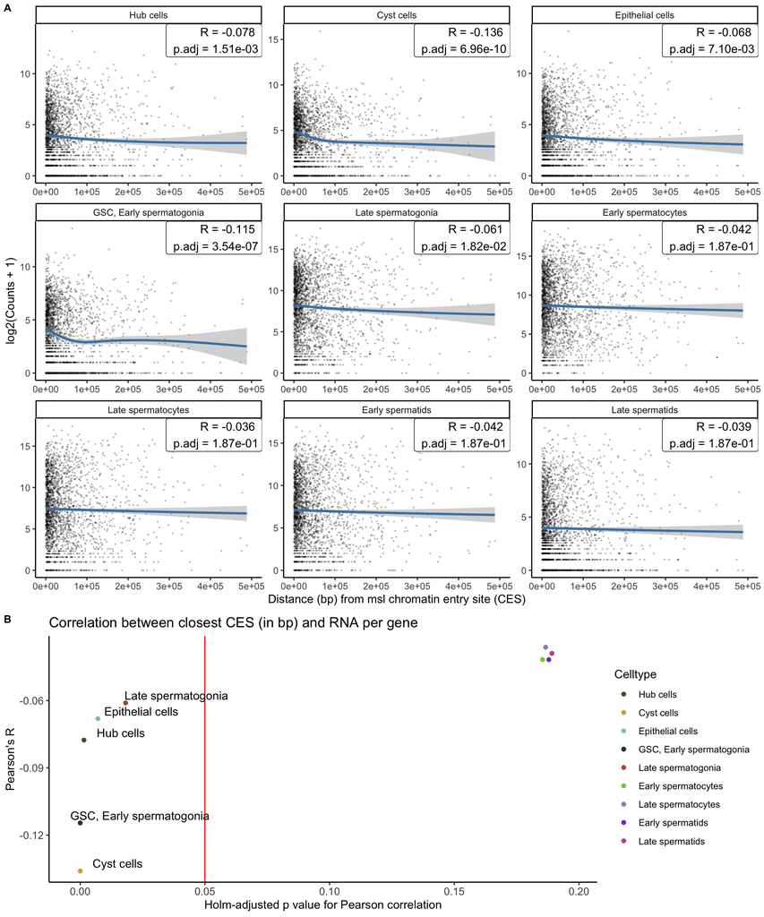

```r
#read in chromatin entry site coordinates
CES<-read.csv("~/Downloads/WittZhao2020data/190927_ChromatinEntrySites_R5.csv", header=TRUE)
CES$R6.start<-as.integer(str_remove_all(CES$R6.start, ","))
CES$R6.end<-as.integer(str_remove_all(CES$R6.start, ","))

#Get start, end, ID, symbol of every dmel gene

flyCDS<-read.table("~/Downloads/WittZhao2020data/dmel-all-r6.15.genes.fb.coords.txt")[,c(1,3,5,6)]
names(flyCDS)<-c("GENEID", "SYMBOL", "start", "end")

#For each gene, get distance from start to closest CES
CESdist<-data.frame()
for (i in flyCDS$SYMBOL[flyCDS$SYMBOL %in% X]){

    dist<-min(abs(subset(flyCDS, SYMBOL==i)$start - CES$R6.start))
    tmp2<-data.frame(Gene=i, distance=dist)
    CESdist<-rbind(CESdist, tmp2)

}

#now, for every gene, make a table with counts and distance to closest CES
#data2<-read.table("~/Downloads/WittZhao2020data/190924_X_autosome_counts.txt")
data2<-read.table("~/Box Sync/Evan/Zhao lab notebook/Misc data/200630_X_autosome_counts.txt")
data2<-subset(data2, Chr=="X")
data2$Celltype<-factor(data2$Celltype, levels=c("Hub cells", "Cyst cells", "Epithelial cells", "GSC, Early spermatogonia", "Late spermatogonia", "Early spermatocytes", "Late spermatocytes", "Early spermatids", "Late spermatids"))
CESdist2<-CESdist
CESdist2$Genename<-CESdist2$Gene
data2<-join(data2,CESdist2)


#get raw and adjusted p values for every cell type correlation.
flycor<-data.frame()
for (i in unique(data2$Celltype)){
  res<-cor.test(x = subset(data2, Celltype== i)$distance, y=log2(subset(data2, Celltype== i)$Counts+1), method = "pearson")
  flycor<-rbind(flycor, data.frame(Celltype=i, pvalue=res$p.value, R=res$estimate))
}

flycor$P.adjust<-p.adjust(flycor$pvalue)
flycor$label<-paste("R =",round(flycor$R,digits=3),"\n", "p.adj =", formatC(flycor$P.adjust, format = "e", digits=2), sep= " ")

#flycor is for supplemental table 3


#this is to label the cell types we care about
Celltypesignif<-c("Hub cells", "Cyst cells", "Epithelial cells", "GSC, Early spermatogonia", "Late spermatogonia", "","","","")

#Figure 4A
p1<-ggplot(data2, aes(x=distance, y=log2(Counts+1)))+geom_point(size=0.2, alpha=0.2)+geom_smooth(color="steelblue")+
  facet_wrap(~`Celltype`, scales='free')+geom_label(data=flycor, aes(x=Inf, y=Inf, label=label), vjust=1, hjust=1)+
  theme_classic()+xlab("Distance (bp) from msl chromatin entry site (CES)")+xlim(0,500000)
#Figure 4B
p2<-ggplot(flycor, aes(x=P.adjust, y=R))+geom_point(aes(color=Celltype), position=position_dodge(width=0.005))+theme_classic()+geom_vline(xintercept=.05, color="red")+ylab("Pearson's R")+xlab("Holm-adjusted p value for Pearson correlation")+ggtitle("Correlation between closest CES (in bp) and RNA per gene")+
  scale_color_manual(aesthetics = c("color","fill"),values = rev(pal))+geom_text(label=Celltypesignif,nudge_x=0.01, hjust=0.25, vjust=-.4)+theme(axis.text=element_text(size=10))

plot_grid(p1, p2, ncol = 1, rel_heights=c(2,1), labels = c("A", "B"), label_size=10)
```

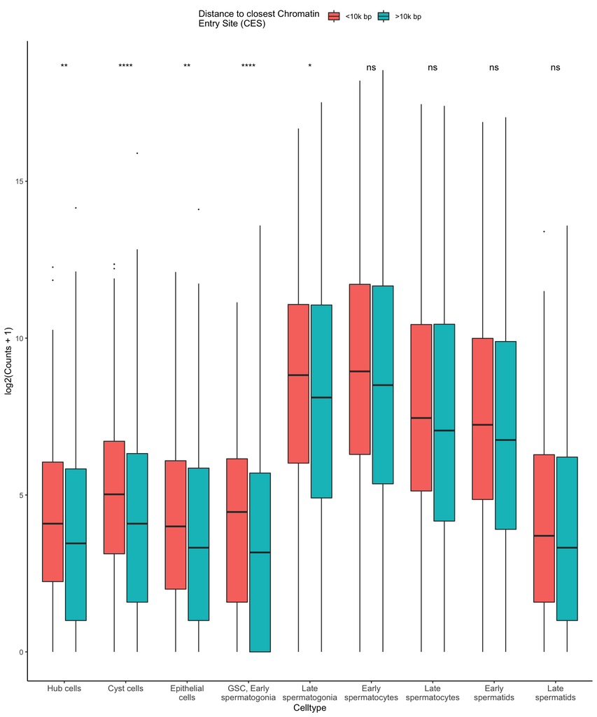

```r
#Supplemental figure 13



#ok make 2 sets: genes within 10000 bp and genes outside

data3<-data2
data3<-mutate(data3, proximity=ifelse(distance<10000, "<10k bp", ">10k bp"))

get_wraper <- function(width) {
    function(x) {
        lapply(strwrap(x, width = width, simplify = FALSE), paste, collapse="\n")
    }
}

ggplot(data3, aes(x=Celltype, y=log2(Counts+1),fill=proximity))+geom_boxplot(outlier.size=.2)+stat_compare_means(method="wilcox.test", aes(label=symnum(..p.adj.., cutpoints = c(0,.00005,  .0005,.005,.05,  1), symbols = c("****","***","**","*","ns") )))+theme_classic()+scale_fill_discrete(name="Distance to closest Chromatin \nEntry Site (CES)")+theme(axis.text.x=element_text(size=10))+
    scale_x_discrete(labels = get_wraper(12))+theme(legend.position="top")
```

```r
#add asterisks







#get table of x and autosome counts: X:autosome, and close:far
data2<-read.table("~/Box Sync/Evan/Zhao lab notebook/Misc data/200630_X_autosome_counts.txt")


data2$Celltype<-factor(data2$Celltype, levels=c("Hub cells", "Cyst cells", "Epithelial cells", "GSC, Early spermatogonia", "Late spermatogonia", "Early spermatocytes", "Late spermatocytes", "Early spermatids", "Late spermatids"))

stat.test2 <- data3 %>%
  group_by(Celltype) %>%
  wilcox_test(Counts ~ proximity ,ref.group = "<10k bp") %>%
  adjust_pvalue(method = "holm") %>%
  add_significance("p.adj") %>%
  add_y_position()

#get table of median summed counts per cell, x and autosome- supplemental table 1
supp1<-data2 %>% dplyr::group_by(Celltype, Chr) %>%
  dplyr::summarize(sum=sum(Counts))%>%
  pivot_wider(names_from=Chr, values_from=sum)

supp1$nCell = c(329, 387, 249, 50, 1048, 1985, 2476, 5964, 512)
supp1$Xpercell=supp1$X/supp1$nCell
supp1$Autopercell=supp1$Autosomal/supp1$nCell
supp1
```

```
## # A tibble: 9 x 6
## # Groups:   Celltype [9]
##   Celltype                 Autosomal        X nCell Xpercell Autopercell
##   <fct>                        <int>    <int> <dbl>    <dbl>       <dbl>
## 1 Hub cells                  2086774   217652   329     662.       6343.
## 2 Cyst cells                 2571118   346498   387     895.       6644.
## 3 Epithelial cells           2155639   225104   249     904.       8657.
## 4 GSC, Early spermatogonia   1121875   163141    50    3263.      22438.
## 5 Late spermatogonia        52260999  6266029  1048    5979.      49867.
## 6 Early spermatocytes      142057175 13505316  1985    6804.      71565.
## 7 Late spermatocytes        78375802  6805856  2476    2749.      31654.
## 8 Early spermatids          51695088  4681180  5964     785.       8668.
## 9 Late spermatids            4950556   435785   512     851.       9669.
```

```r
supp1$ratio<-supp1$Xpercell/supp1$Autopercell
```

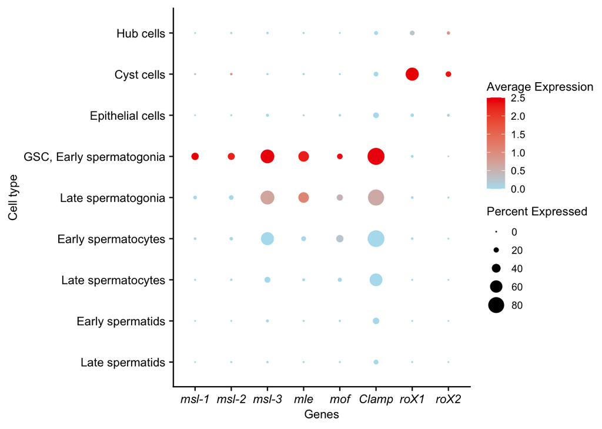

```r
#ok let's add another figure with a dotplot of msl genes.  I'll add some FISH pictures using illustrator.
levels(testis.integrated)<-rev(c("Hub cells", "Cyst cells", "Epithelial cells", "GSC, Early spermatogonia", "Late spermatogonia", "Early spermatocytes", "Late spermatocytes", "Early spermatids", "Late spermatids"))
p2<-DotPlot(testis.integrated, assay = "RNA", features = rev(c("msl-1", "msl-2", "msl-3", "mle", "mof", "Clamp", "roX1", "roX2")), cols=c("lightblue2",  "red2"), col.min = 0)
p2<-p2+theme(text=element_text(size=10), axis.text.x=element_text(size=10, face = "italic"), axis.text.y=element_text(size=10, face="plain"))+xlab("Genes")+ylab("Cell type")
p2
```

[figure not shown]

```r
#ggsave("~/Box Sync/Evan/Zhao lab notebook/Writing/DC paper revisions/200629_Figure5.pdf", width=8, height=4)

p1<-RidgePlot(testis.integrated, features = "msl-1", slot="counts")+theme(legend.position="none")
p2<-RidgePlot(testis.integrated, features = "msl-2", slot="counts")+theme(legend.position="none", axis.text.y=element_blank())
p3<-RidgePlot(testis.integrated, features = "msl-3", slot="counts")+theme(legend.position="none", axis.text.y=element_blank())+xlim(0,15)
p4<-RidgePlot(testis.integrated, features = "mle", slot="counts")+theme(legend.position="none", axis.text.y=element_blank())
p5<-RidgePlot(testis.integrated, features = "mof", slot="counts")+theme(legend.position="none")
p6<-RidgePlot(testis.integrated, features = "Clamp", slot="counts")+theme(legend.position="none", axis.text.y=element_blank())+xlim(0,15)
p7<-RidgePlot(testis.integrated, features = "roX1", slot="counts")+theme(legend.position="none", axis.text.y=element_blank())
p8<-RidgePlot(testis.integrated, features = "roX2", slot="counts")+theme(legend.position="none", axis.text.y=element_blank())



p1<-VlnPlot(testis.integrated, features = "msl-1", slot="counts")+theme(legend.position="none")+ylab("Counts")+xlab("Cell type")
p2<-VlnPlot(testis.integrated, features = "msl-2", slot="counts")+theme(legend.position="none")+ylab("Counts")+xlab("Cell type")
p3<-VlnPlot(testis.integrated, features = "msl-3", slot="counts")+theme(legend.position="none")+ylab("Counts")+xlab("Cell type")
p4<-VlnPlot(testis.integrated, features = "mle", slot="counts")+theme(legend.position="none")+ylab("Counts")+xlab("Cell type")
p5<-VlnPlot(testis.integrated, features = "mof", slot="counts")+theme(legend.position="none")+ylab("Counts")+xlab("Cell type")
p6<-VlnPlot(testis.integrated, features = "Clamp", slot="counts")+theme(legend.position="none")+ylab("Counts")+xlab("Cell type")
p7<-VlnPlot(testis.integrated, features = "roX1", slot="counts")+theme(legend.position="none")+ylab("Counts")+xlab("Cell type")
p8<-VlnPlot(testis.integrated, features = "roX2", slot="counts")+theme(legend.position="none")+ylab("Counts")+xlab("Cell type")

#VlnPlot(testis.integrated, features = c("msl-1","msl-2","msl-3","mle","mof","Clamp", "roX1", "roX2"), slot="counts")

#VlnPlot(testis.integrated, features = c("msl-1","msl-2","msl-3","mle","mof","Clamp", "roX1", "roX2"), slot="counts")
p9<-ggdraw()+draw_image("~/Box Sync/Evan/Zhao lab notebook/Misc_data/DCC-images/msl1.png")+p1
p10<-ggdraw()+draw_image("~/Box Sync/Evan/Zhao lab notebook/Misc_data/DCC-images/msl2.png")+p2
p11<- ggdraw()+draw_image("~/Box Sync/Evan/Zhao lab notebook/Misc_data/DCC-images/msl3.png")+p3
p12<-ggdraw()+draw_image("~/Box Sync/Evan/Zhao lab notebook/Misc_data/DCC-images/mle.png")+p4
p13<-ggdraw()+draw_image("~/Box Sync/Evan/Zhao lab notebook/Misc_data/DCC-images/roX1.png")+p7
p14<-ggdraw()+draw_image("~/Box Sync/Evan/Zhao lab notebook/Misc_data/DCC-images/roX2.png")+p8

plot_grid(p7,p8,p1,p2,p3,p4, nrow=2)
```

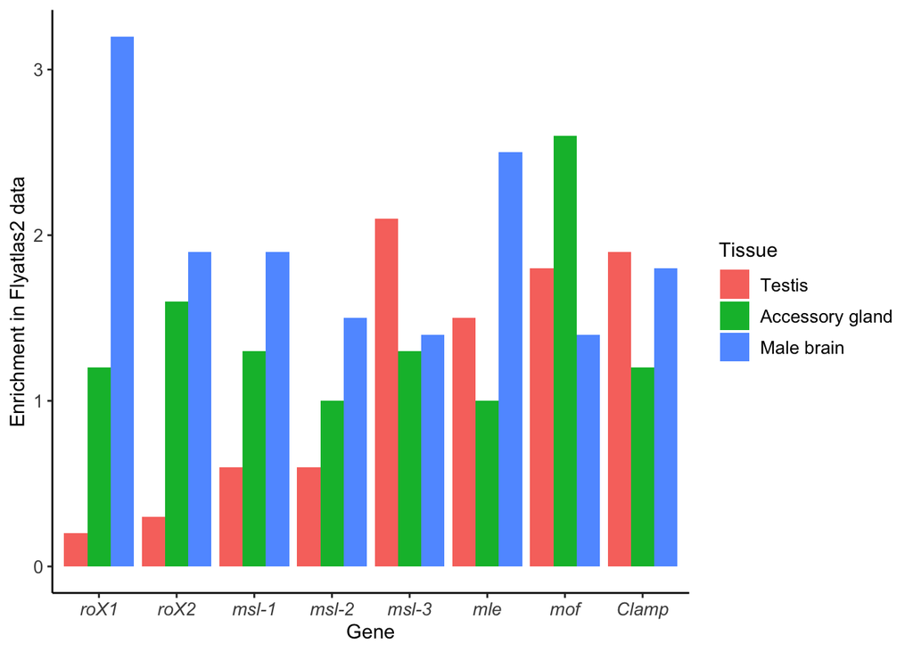

```r
#pdf("~/Box Sync/Evan/Zhao lab notebook/Misc_data/DCC-images/msl1.pdf", width=8, height=6)
#p9
#dev.off()
#pdf("~/Box Sync/Evan/Zhao lab notebook/Misc_data/DCC-images/msl2.pdf", width=8, height=6)
#p10
#dev.off()
#pdf("~/Box Sync/Evan/Zhao lab notebook/Misc_data/DCC-images/msl3.pdf", width=8, height=6)
#p11
#dev.off()
#pdf("~/Box Sync/Evan/Zhao lab notebook/Misc_data/DCC-images/mle.pdf", width=8, height=6)
#p12
#dev.off()
#pdf("~/Box Sync/Evan/Zhao lab notebook/Misc_data/DCC-images/roX1.pdf", width=8, height=6)
#p13
#dev.off()
#pdf("~/Box Sync/Evan/Zhao lab notebook/Misc_data/DCC-images/roX2.pdf", width=8, height=6)
#p14
#dev.off()


#flyatlas expression#supplemental figure 14

flyatlas<-read.csv("~/Downloads/WittZhao2020data/DCC-gene-fpkm.csv")
flyatlas<-flyatlas %>%pivot_longer(c(Testis.enrichment, Accessory.gland.enrichment, Male.brain.enrichment), names_to="Tissue", values_to="Enrichment")
flyatlas$Tissue<-gsub(flyatlas$Tissue, pattern="Accessory.gland.enrichment", replacement="Accessory gland")
flyatlas$Tissue<-gsub(flyatlas$Tissue, pattern="Testis.enrichment", replacement="Testis")
flyatlas$Tissue<-gsub(flyatlas$Tissue, pattern="Male.brain.enrichment", replacement="Male brain")

flyatlas$Tissue<-factor(flyatlas$Tissue, levels=c("Testis", "Accessory gland", "Male brain"))
flyatlas$X<-factor(flyatlas$X, levels=c("roX1", "roX2", "msl-1", "msl-2", "msl-3", "mle", "mof", "Clamp"))
ggplot(flyatlas, aes(x=X, y=Enrichment, fill=Tissue))+geom_bar(position="dodge", stat="identity")+theme_classic()+xlab("Gene")+ylab("Enrichment in Flyatlas2 data")+theme(axis.text.x = element_text(size=10, face="italic"),legend.text=element_text(size=10), axis.text.y=element_text(size=10))
```

Yay you did it! Feel free to tinker with this code however you want- if you want to assign cell types differently, or do an entirely different analysis, go ahead! There’s lots of stories buried in there, just remember to cite Witt and Zhao 2020 when you publish! Thanks for reading!